# Продвинутые темы

Часть 3

Казначеев С.И.

Российский университет дружбы народов, Москва, Россия Россия

14 мая 2025

# Информация

## Докладчик

- Казначеев Сергей Ильич
- Студент
- Российский университет дружбы народов
- [1132240693@pfur.ru]

# Вводная часть

## Задание 1

Чтобы выйти из редактора vim нужно нажать ” : “, затем”q”, затем “Еnter”

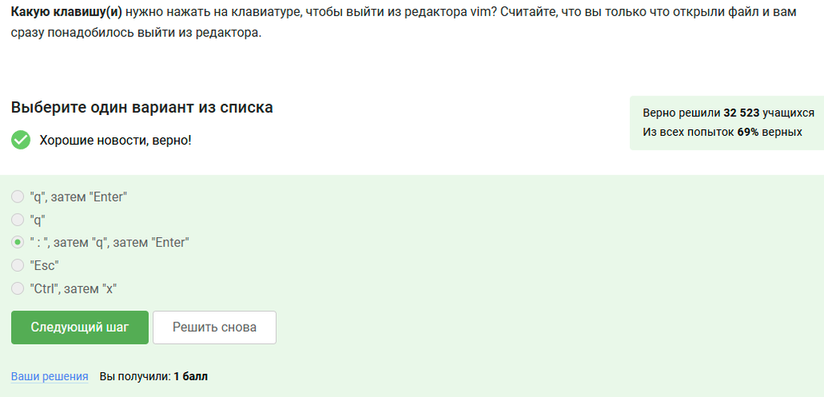

sc1

## Задание 2

Главное различие между word и WORD чтобы попасть в конец строки нужно совершить меньше нажатий на W чем на w

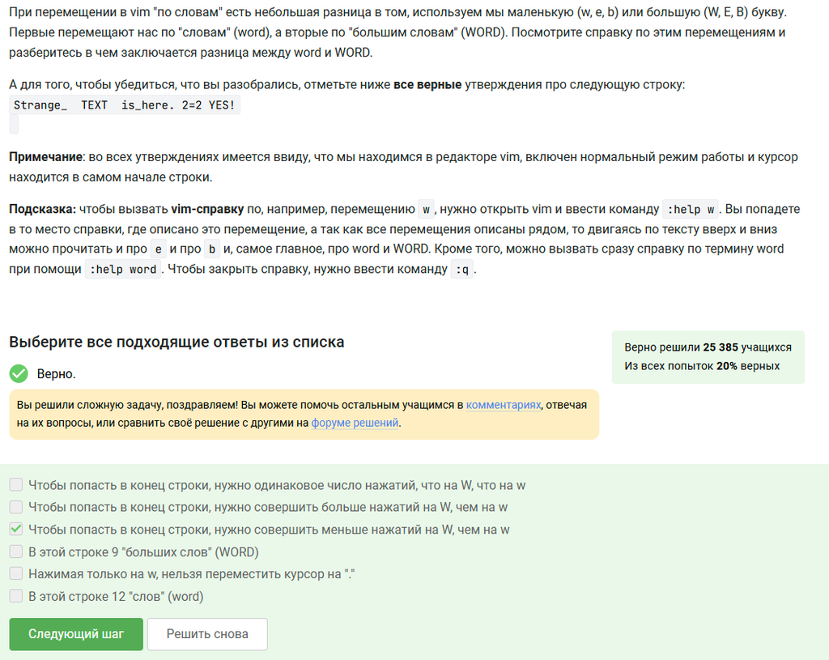

sc2

## Задание 3

Чтобы отредактировать данный текст one two three four five в three four four four five нам понадобится

1)d2w$$bifour four <> 2)ddithree four four four five <> 3)d2wwifour four <>

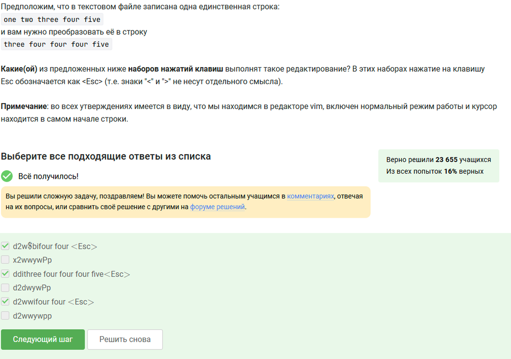

sc3

## Задание 4

Чтобы заменить слово Windows на Linux нам понадобится команда

сама команда :%s/Windows/Linux

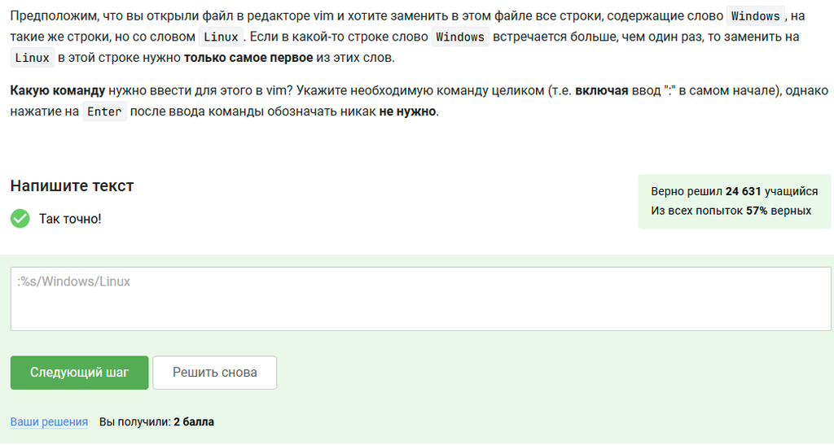

sc4

## Задание 5

Существует третий режим vim - режим выделения

1)Режим выделения открывается из нормального режима по нажатию “v” 2)В режиме выделения можно использовать команды d (удалить) и y (скопировать) 3)Выйти из режима выделения можно, нажав клавишу Esc два раза 4)В режиме выделения можно использовать команды перемещения (например, W, e, $, и др.)

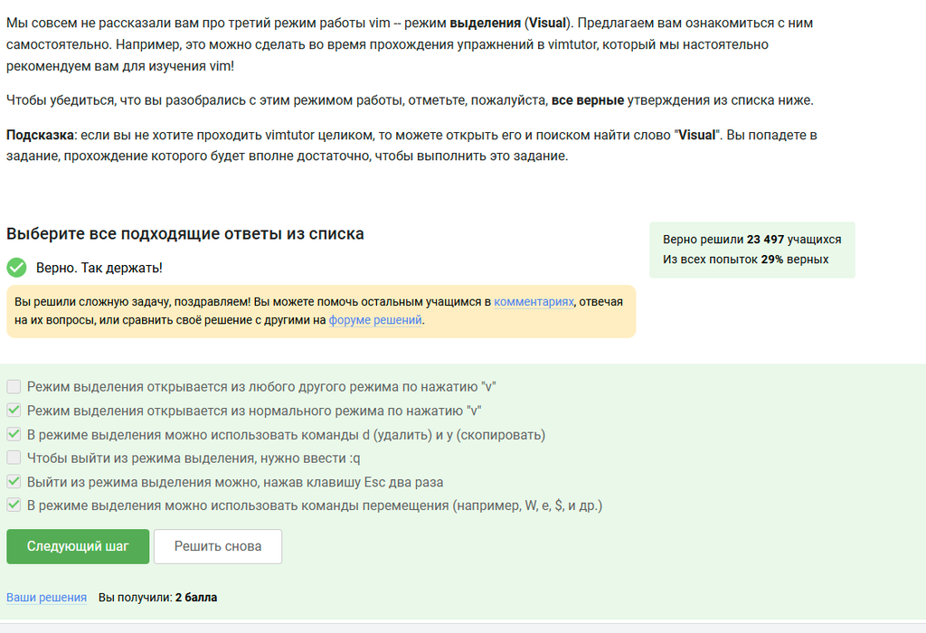

sc5

## Задание 6

Только C

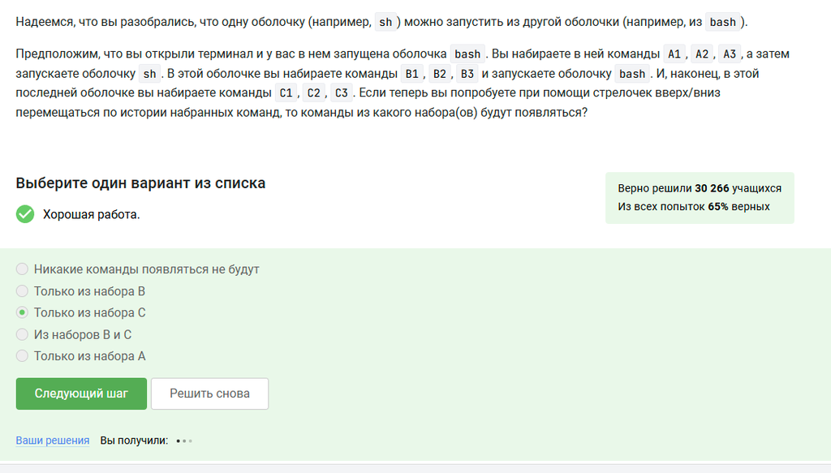

sc6

## Задание 7

После изучения скрипта абсолютный путь будет выглядеть /home/bi/file1.txt

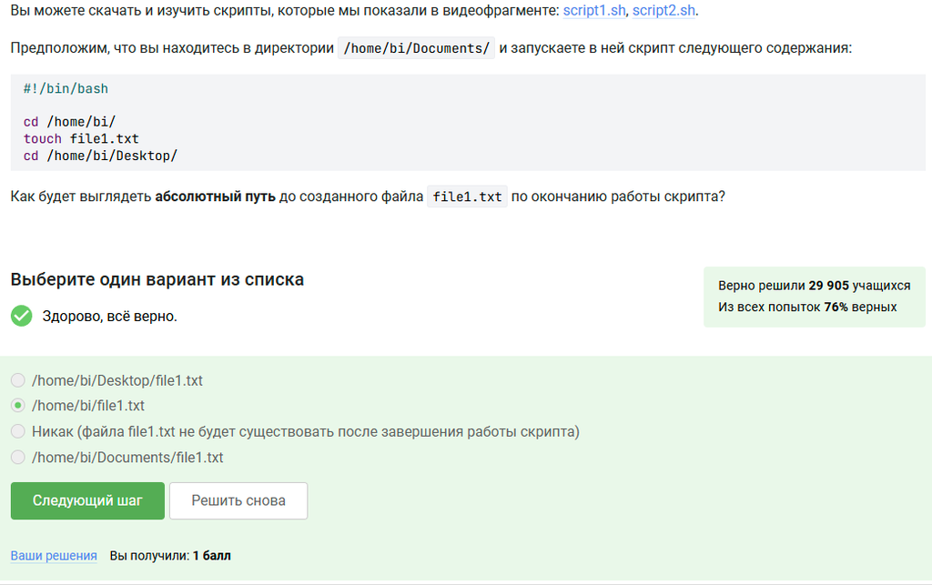

sc7

## Задание 8

Именами переменных в bash могут быть:

1)variable123 2)variable_123 3)VARiable 4)__variable

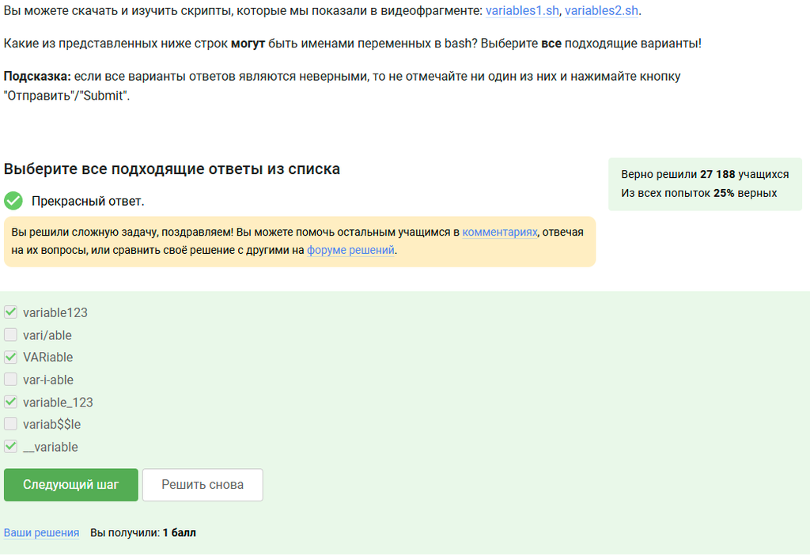

sc8

## Задание 9

Напишем скрипт на bash который принимает на вход два аргумента и выводит на экран строку следующего вида - Arguments are: $1=первый_аргумент $2=второй_аргумент

Сам код

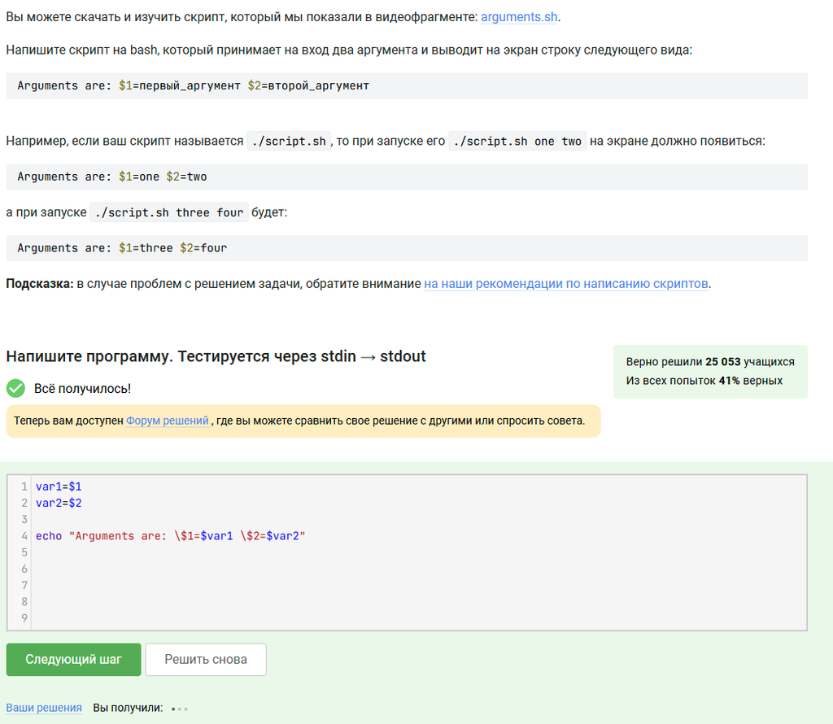

sc9

## Задание 10

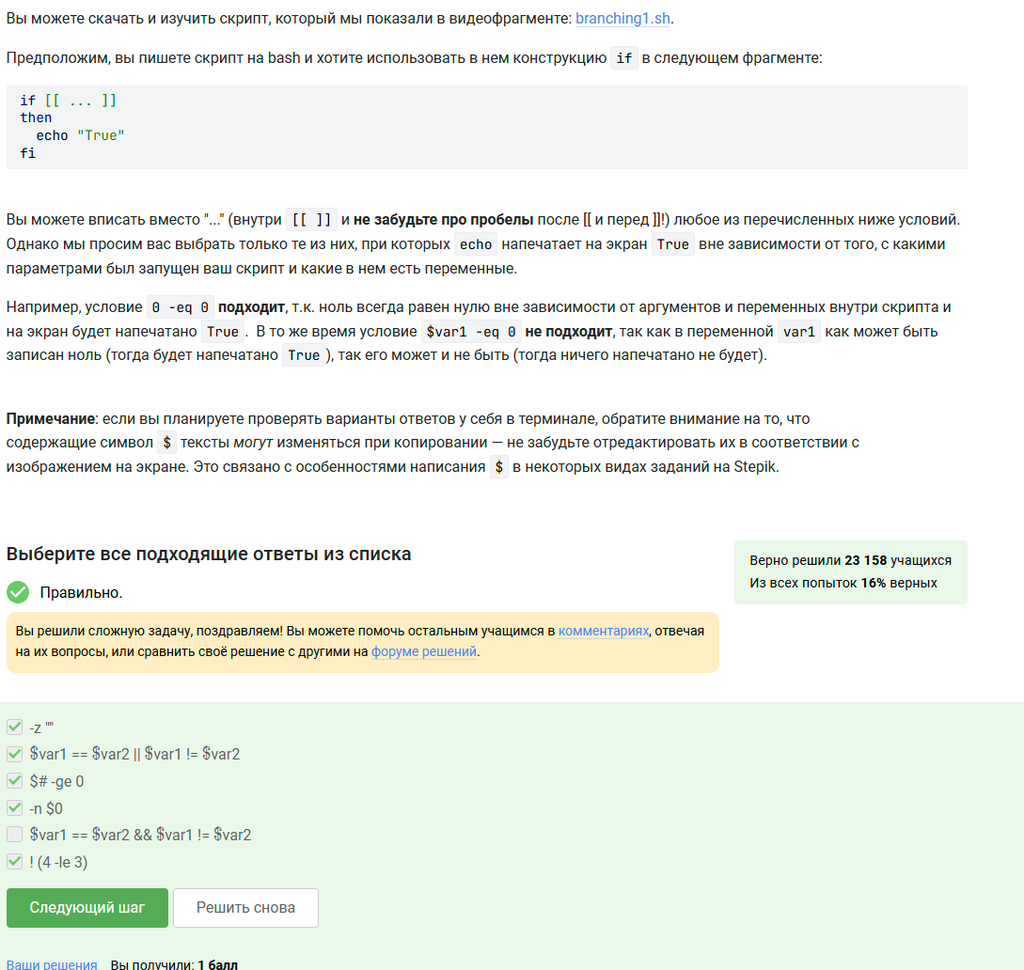

sc10

## Задание 11

Сначала var=3 затем var=5 у нас он выведет Сначала four, потом four

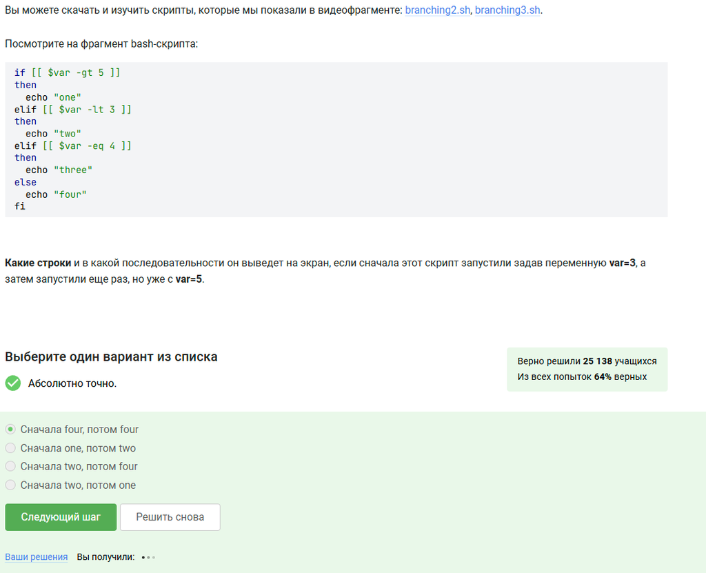

sc11

## Задание 12

Напишем скрипн на bash который принимает на вход один аргумент который будет обозначать число студентов в аудитории

Сам скрипт if [[ $1 -eq 1 ]]; then echo “$1 student” elif [[ $1 -gt 1 && $1 -le 4 ]]; then echo “$1 students” elif [[ $1 -ge 5 ]]; then echo “A lot of students” else echo “No students” fi

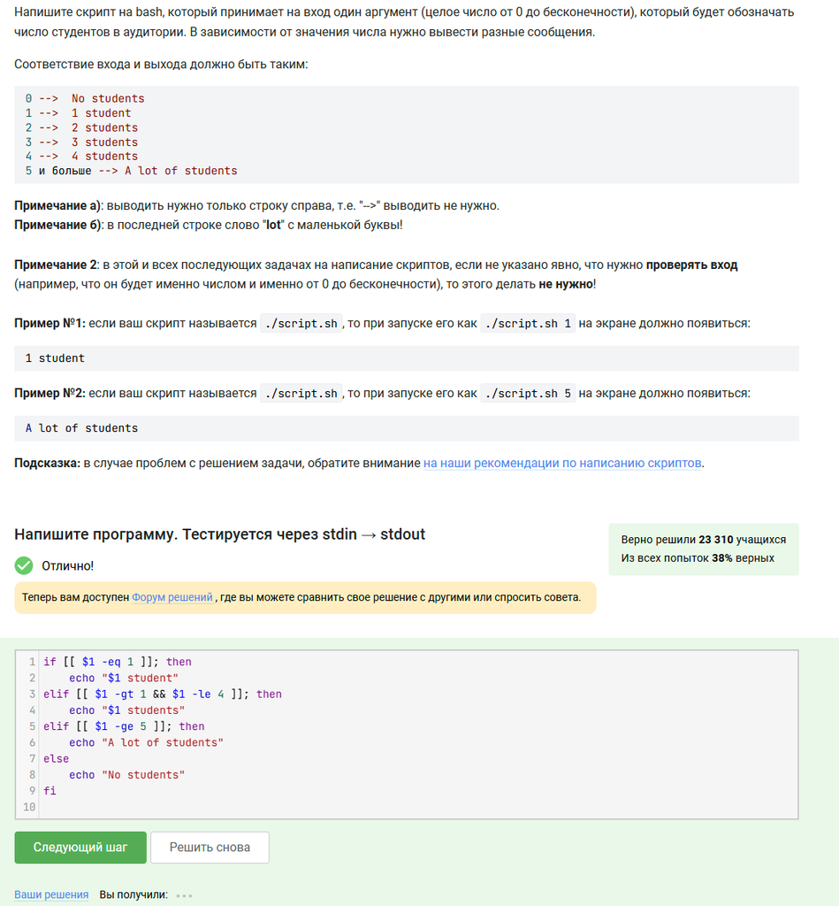

sc12

## Задание 13

После запуска скрипта у на выведится 5 start раз и 4 раза finish

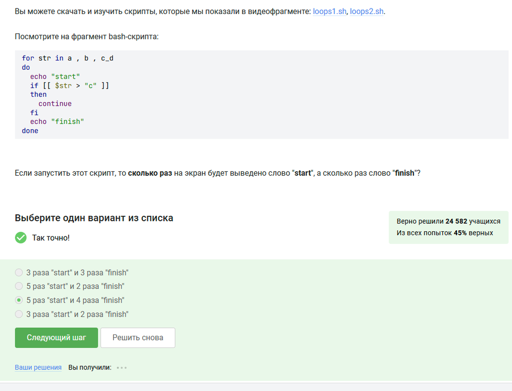

sc13

## Задание 14

Напишем скрипн на bash который будет определять в какую возрастную группу попадают пользователи скрипт будет представлен на скрине

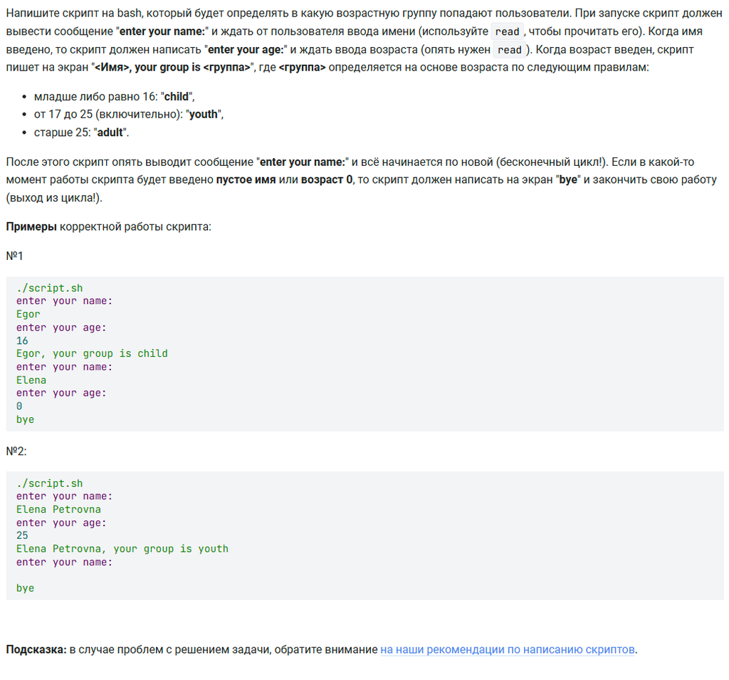

sc14

## Код

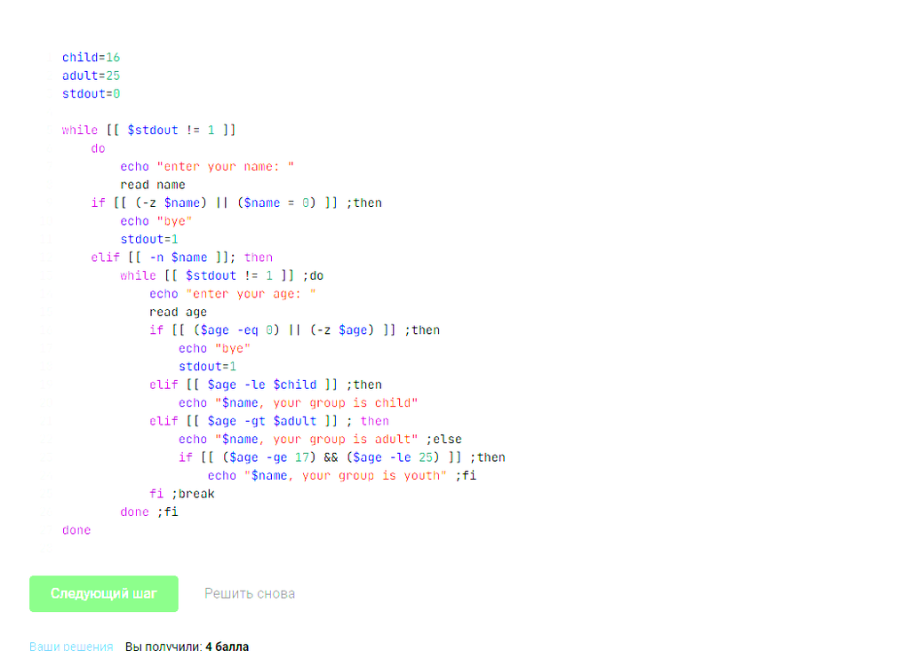

sc15

## Задание 15

Из ниже предложенных вариантов ответа увеличивает число а на значение б

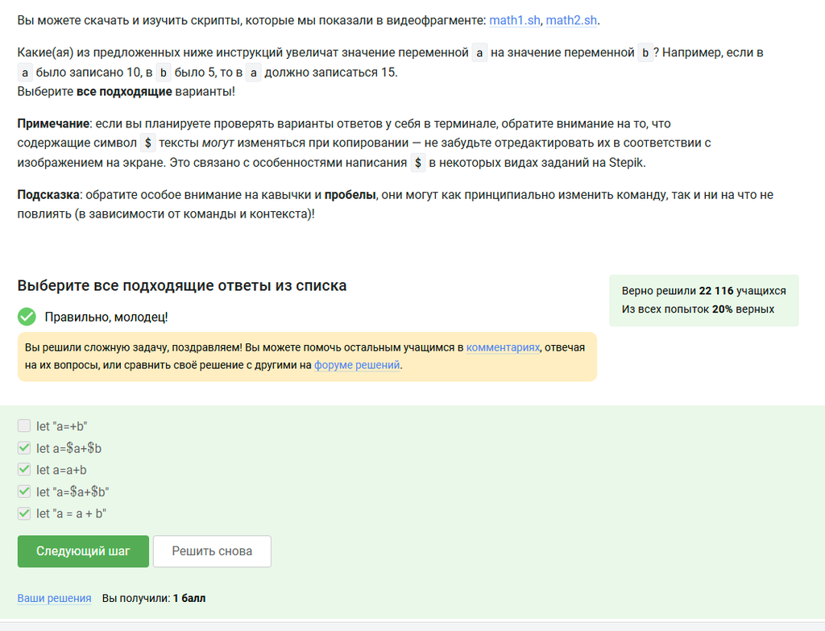

sc16

## Задание 16

Команда выведет /home/bi

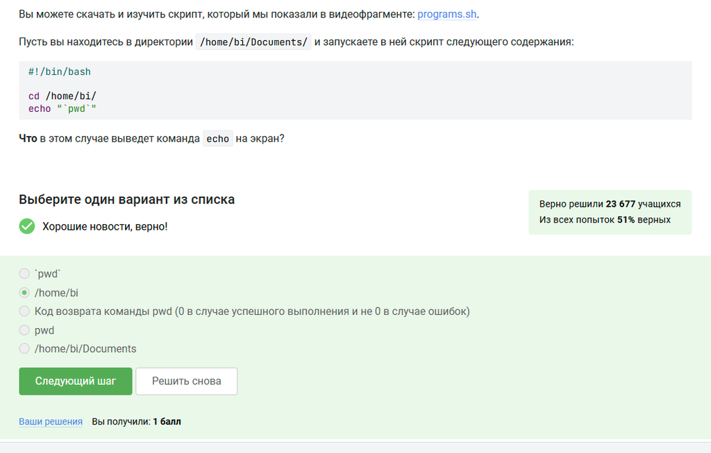

sc17

## Задание 17

Ответ

1)if `program > some_file.txt` 2)Сначала запустить program, затем if [[ $? -eq 0 ]]

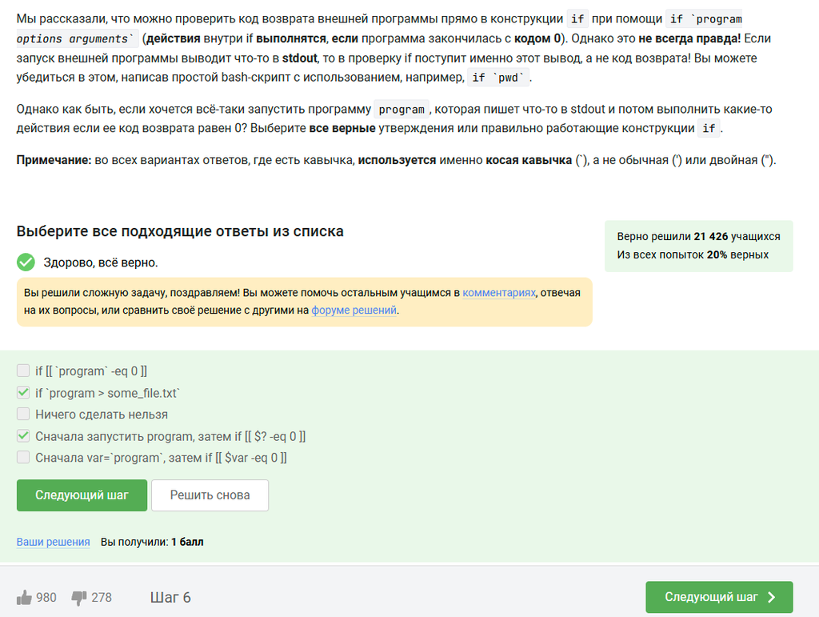

sc18

## Задание 18

Команда echo “counters are $c1 and $c2” выведет на экран counters are and 110

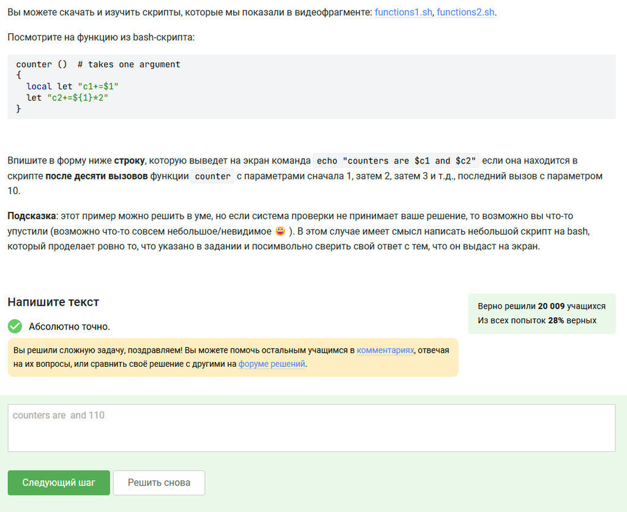

sc19

## Задание 19

Напишем скрипнт на bash который будет искать наибольший общий делитель

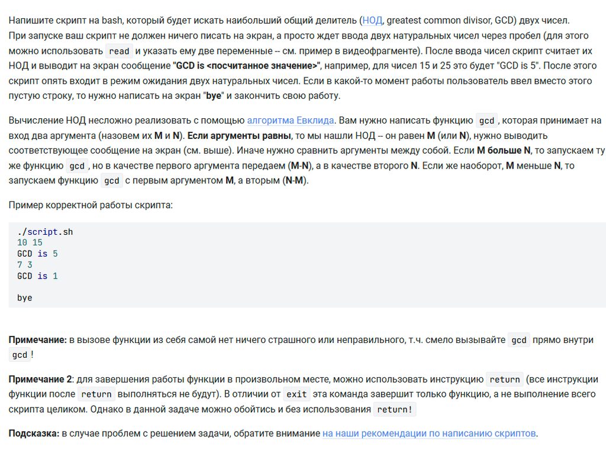

sc20

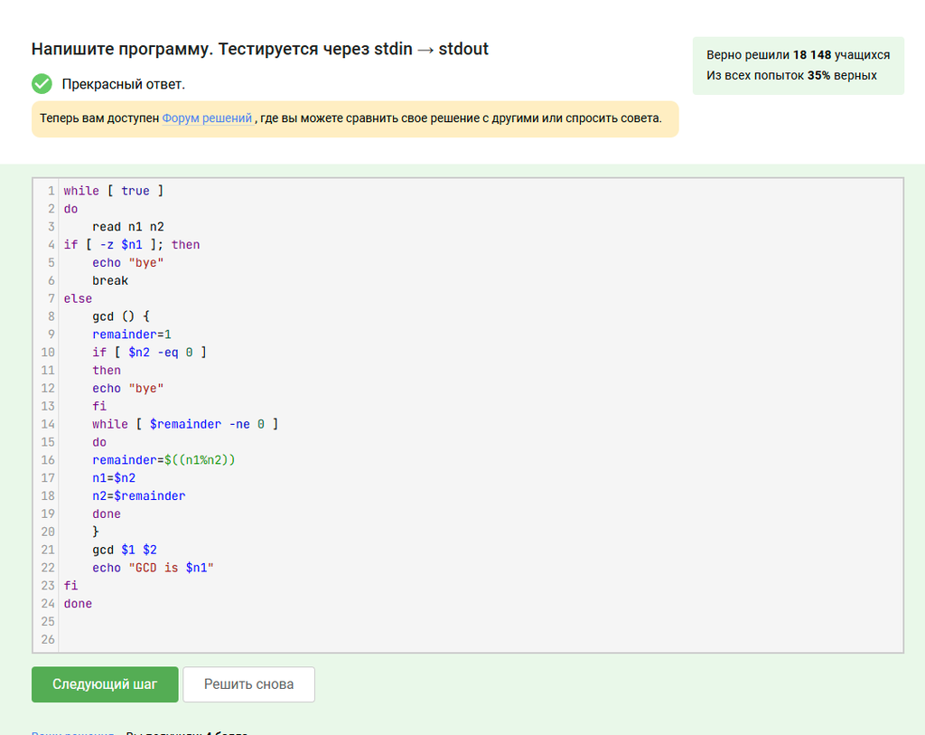

sc21

## Задание 20

Напишем калькулятор на bash

Сам скрипт

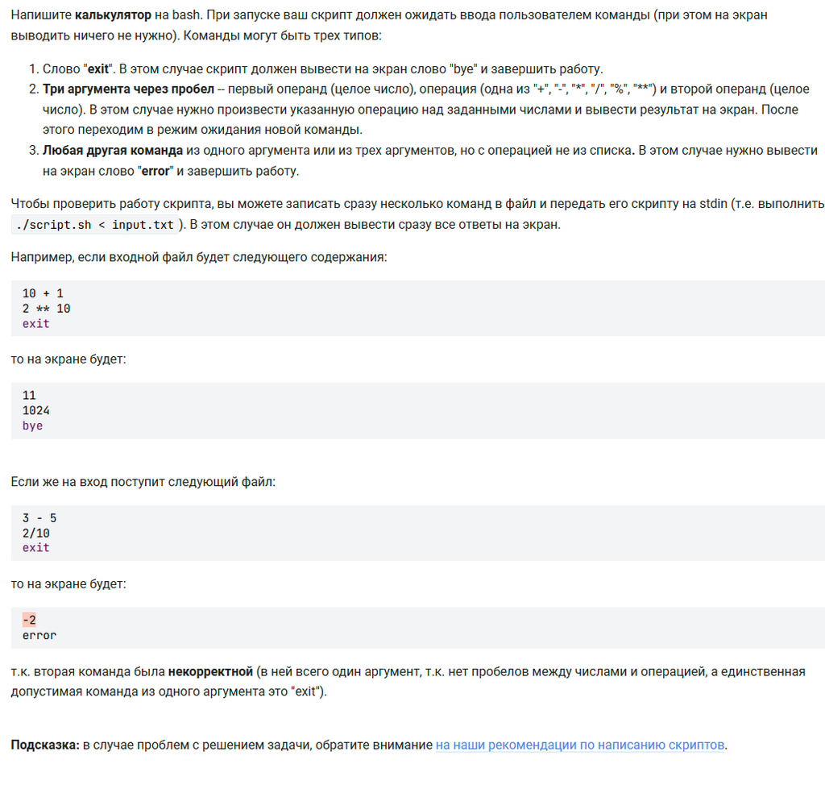

sc22

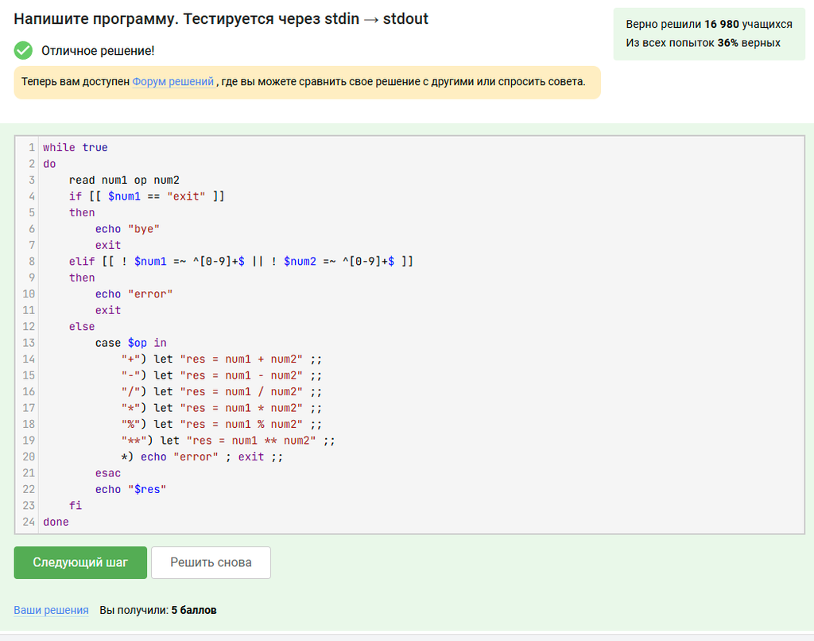

sc23

## Задание 21

Команда find /home/bi -iname “star*” но не найдет find /home/bi -name ”star*”

1)STARS.txt 2)Star_Wars.avi

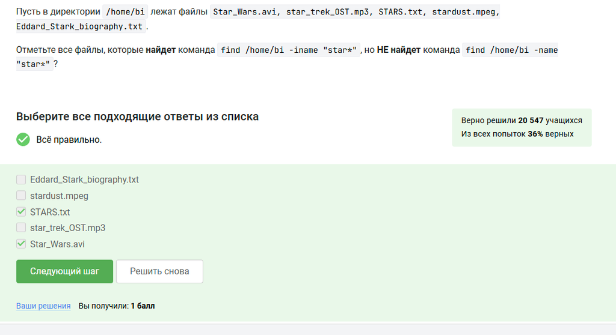

sc24

## Задание 22

Команды -path и -name если заменить в команде -name на -path то результат поиска иногда может остаться таким же

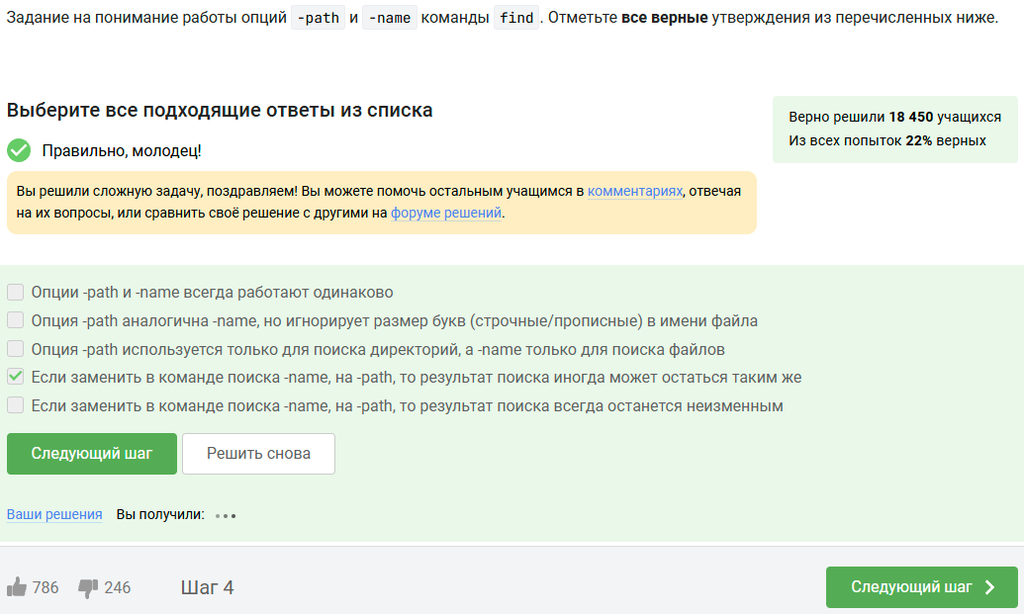

sc25

## Задание 23

Из данных трех файлов (file1, file2, file3) будут найдены все кроме file3

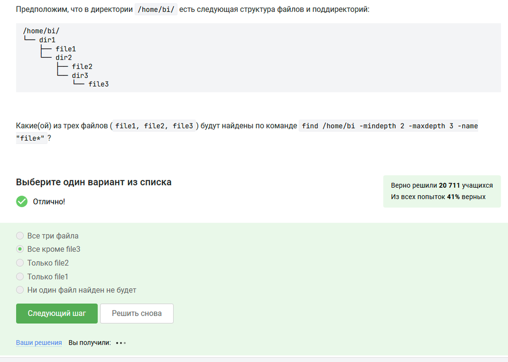

sc26

## Задание 24

После выполнения всех команда у нас будет results.txt будет одинакового размера во всех случаях

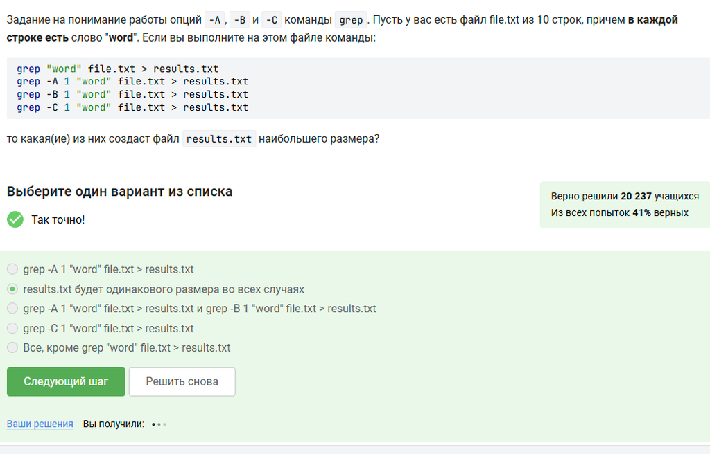

sc27

## Задание 25

После команды grep -E “[xklXKL]?[uU]buntu$” text.txt. у нас выведется

1)Linux is not always Ubuntu 2)Hmm, XKLubuntu 3) Mac OS X, Windows, Ubuntu 4)I prefer Kubuntu 5)Lubuntu is better than Ubuntu 6)The best OS is Xubuntu

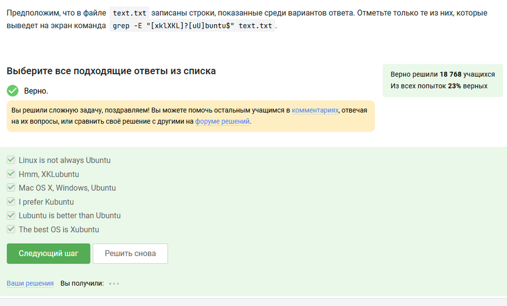

sc28

## Задание 26

Если в команде sed -n “/[a-z]*/p” text.txt не указывать опцию -n у нас будет каждая строчка выведена два раза

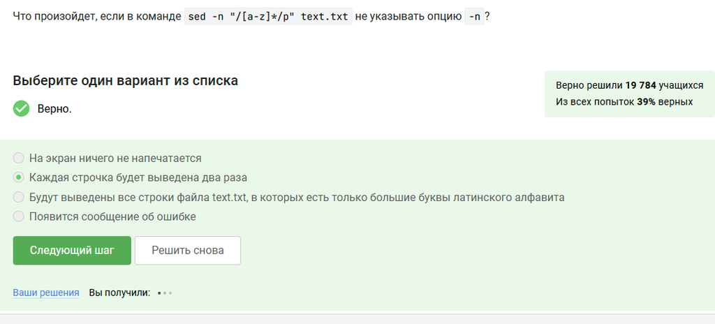

sc29

## Задание 27

Ответ sed “s/ [A-Z]+[A-Z]+ / abbreviation /g” input.txt > edited.txt

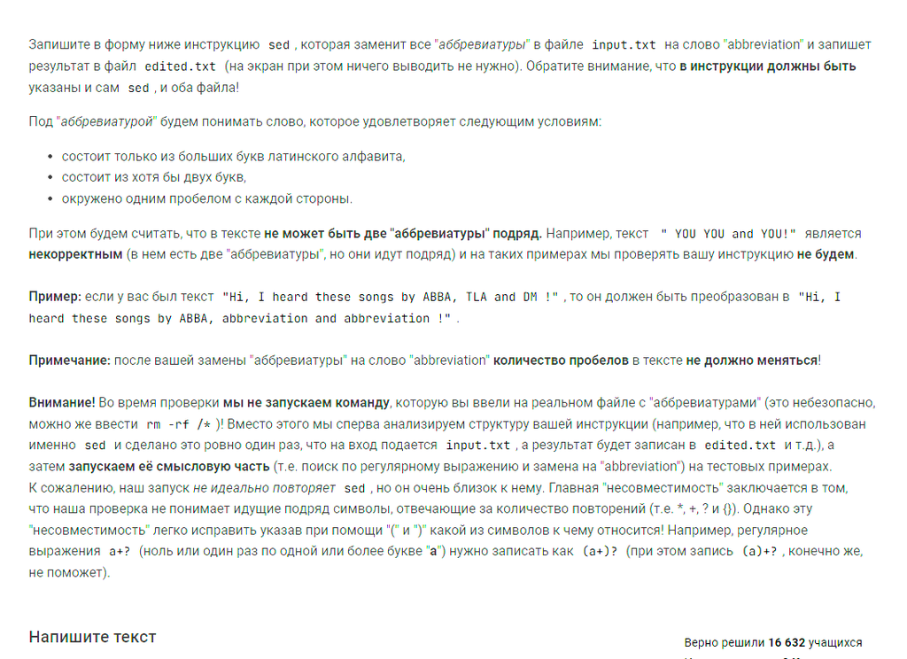

sc30

## Код

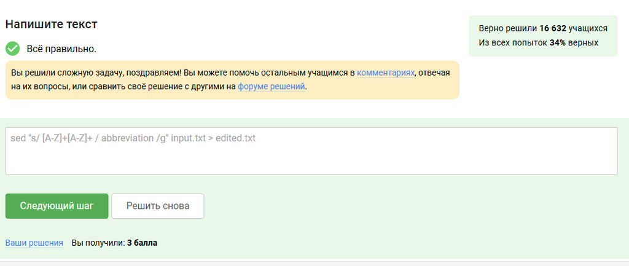

sc31

## Задание 28

При запуске gnuplot можно указать опцию -p, –persist

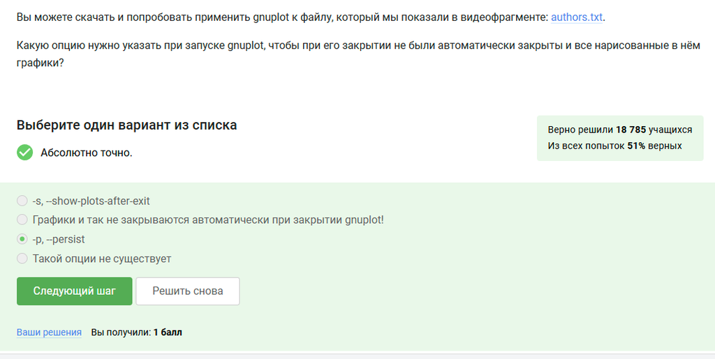

sc30